# hw4

Connor Hergenreter

March 6, 2019

## Homework #4

## Attaching packages

```r
library(ggplot2)
library(dplyr)
```

## Question 1

Information based on diet can be shown using summarize(). This returns a tibble with the number of feedings per diet, mean chick weight on diet, and standard deviation of weight on diet.

```r
weight0 <- ChickWeight %>% group_by(Diet) %>% summarize(Occurrences =n(), Mean_Weight=mean(weight, na.rm=TRUE), Weight_Std_Dev=sd(weight, na.rm=TRUE))
print(weight0)
```

```
## # A tibble: 4 x 4
##   Diet  Occurrences Mean_Weight Weight_Std_Dev
##   <fct>       <int>       <dbl>          <dbl>
## 1 1             220        103.           56.7
## 2 2             120        123.           71.6
## 3 3             120        143.           86.5
## 4 4             118        135.           68.8
```

## Question 2

The following block only adds a column that displays the total number of feedings per chick. If the number is not equal to 12, then those rows are dropped. There are 45 chicks with 12 recordings.

```r
complete <- ChickWeight %>% group_by(Chick) %>% mutate(Num_Feed=n()) %>% filter(Num_Feed==12) %>% select(-Num_Feed)

print(tbl_df(complete), n=3)
```

```
## # A tibble: 540 x 4
##   weight  Time Chick Diet
##    <dbl> <dbl> <ord> <fct>
## 1     42     0 1     1
## 2     51     2 1     1
## 3     59     4 1     1
## # ... with 537 more rows
```

## Question 3

The weight gain column is added by adding a column that records the difference between current weight and previous weight. Now the weight gain column can be created by making a running total of weight gain.

```r
complete <- complete %>% group_by(Chick) %>%  mutate(differ=(weight - lag(weight, default=weight[1])), weightgain=cumsum(differ)) %>% select(-differ)

print(tbl_df(complete), n=3)
```

```
## # A tibble: 540 x 5
##   weight  Time Chick Diet  weightgain
##    <dbl> <dbl> <ord> <fct>      <dbl>
## 1     42     0 1     1              0
## 2     51     2 1     1              9
## 3     59     4 1     1             17
## # ... with 537 more rows
```

## Question 4

Using the following boxplots it appears that chicks on diet 1 gained the least weight on average while chicks on diet 3 gained the most. Weight gain varied the most with diet 2 and the least with diet 4.

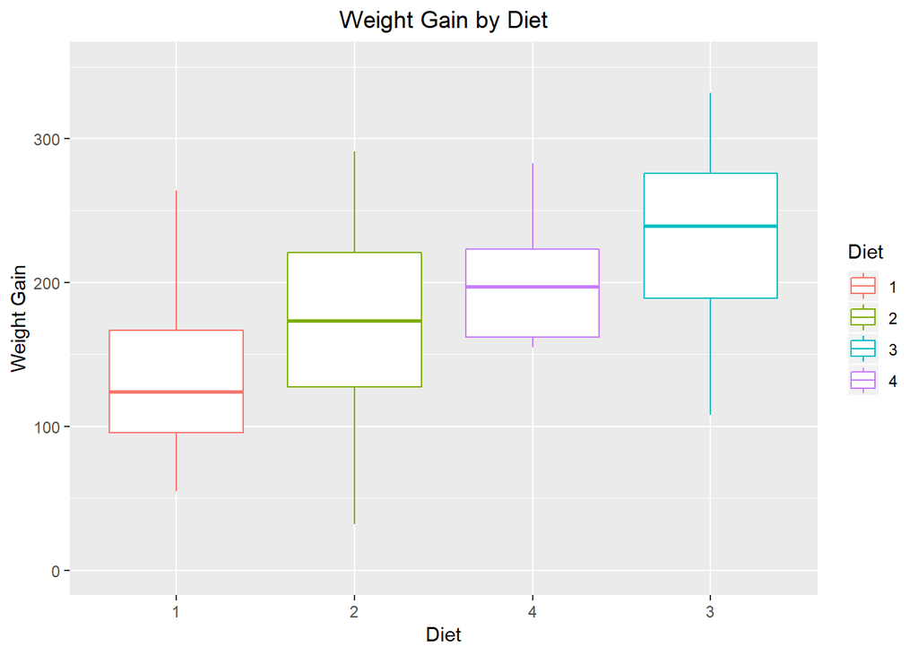

```r
compbox <- complete %>% filter(Time==21)

ggplot(compbox, aes(x=reorder(Diet, weightgain, FUN=median), y=weightgain, color=Diet)) + geom_boxplot() + coord_cartesian(ylim=c(0,350)) + labs(title="Weight Gain by Diet", x="Diet", y="Weight Gain") + theme(plot.title=element_text(hjust=0.5))
```

## Question 5

The following table and graph show that chick 24 gained the least while chick 35 gained the most. Chick 24 was on diet #2 and chick 35 was on diet #3.

```r
compsum <- complete %>% group_by(Chick, Diet) %>% summarize(Total_Gain=max(weightgain)) %>% arrange(Total_Gain)

print(tbl_df(compsum), n=45)
```

```
## # A tibble: 45 x 3
##    Chick Diet  Total_Gain
##    <ord> <fct>      <dbl>
##  1 24    2             34
##  2 13    1             55
##  3 9     1             58
##  4 20    1             76
##  5 10    1             83
##  6 17    1            100
##  7 19    1            114
##  8 30    2            115
##  9 33    3            117
## 10 4     1            118
## 11 6     1            119
## 12 22    2            126
```

[output cut: 33 more lines]

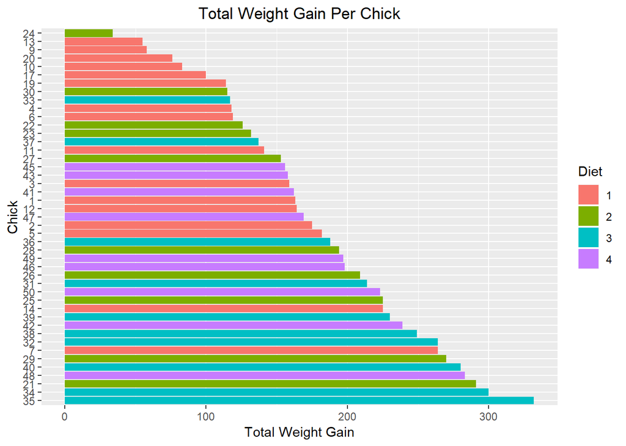

```r
ggplot(compsum, aes(x=reorder(Chick, -Total_Gain), y=Total_Gain, fill=Diet)) + geom_bar(stat="identity") + coord_flip() + labs(title="Total Weight Gain Per Chick",x="Chick",y="Total Weight Gain") + theme(plot.title=element_text(hjust=0.5))
```

## Question 6

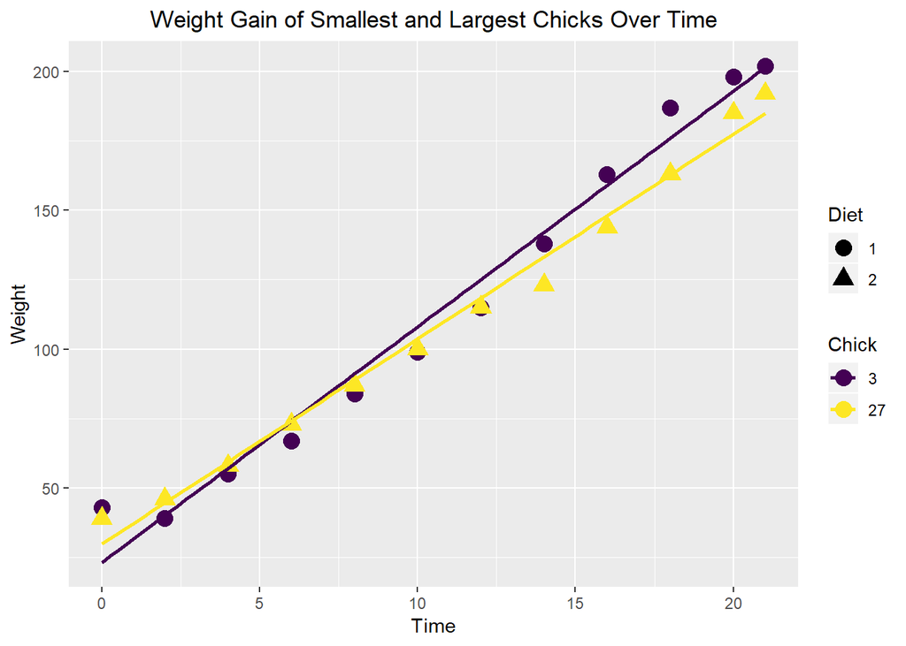

```r
firstdate <- complete %>% filter(Time==0) %>% arrange(weight)
smallchick <- firstdate$Chick[which.min(firstdate$weight)]
bigchick <- firstdate$Chick[which.max(firstdate$weight)]
scatterchick <- complete %>% filter(Chick==smallchick | Chick==bigchick)

ggplot(scatterchick, aes(x=Time, y=weight, shape=Diet, color=Chick)) + geom_point(size=4) + geom_smooth(method=lm, se=FALSE, fullrange=TRUE) + labs(title="Weight Gain of Smallest and Largest Chicks Over Time",y="Weight") + theme(plot.title=element_text(hjust=0.5))
```

## Question 7

After seeing the boxplots from question 4 I wanted to check out how the scatterplot for the diets looked. Diet 2 looks really interesting in my opinion. It appears that some chickens did not take to the diet very well while others did very well on it. The plot was good to see how much weight varied in diet 2. Diet 4 is very tightly clustered in comparison to the other diets, just as how the boxplots displayed it.

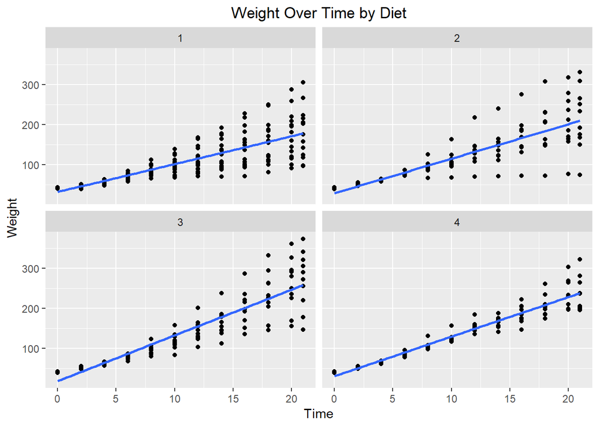

```r
ggplot(complete, aes(x=Time, y=weight)) + geom_point() + facet_wrap(~Diet) + geom_smooth(method=lm, se=FALSE, fullrange=TRUE) + labs(title="Weight Over Time by Diet", y="Weight") + theme(plot.title=element_text(hjust=0.5))
```

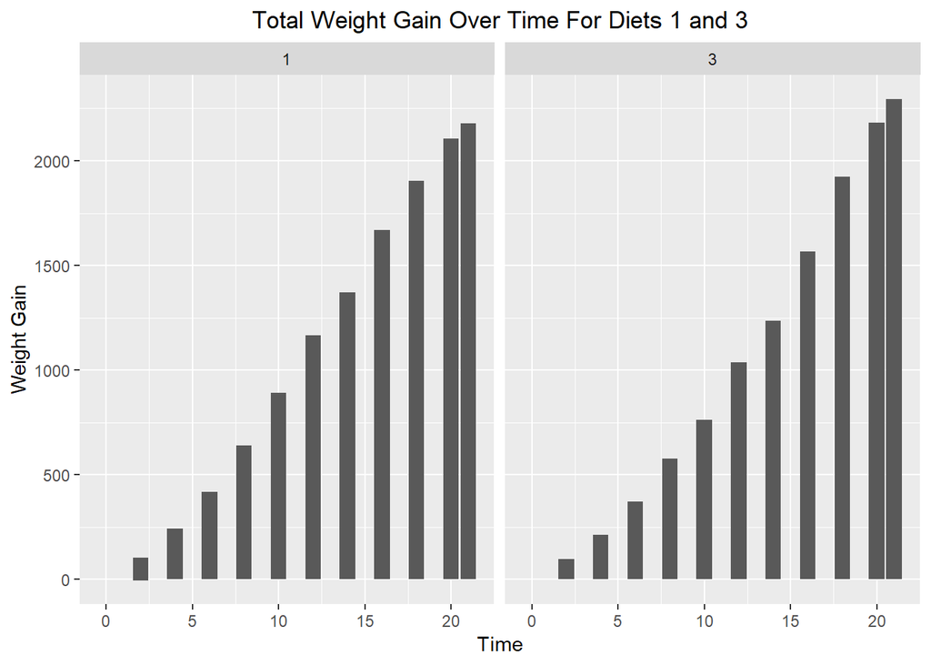

```r
comparisoncomp <- complete %>% filter(Diet==1 | Diet==3)

ggplot(comparisoncomp, aes(x=Time, y=weightgain)) + geom_bar(stat="identity") + facet_grid(~Diet) + labs(title="Total Weight Gain Over Time For Diets 1 and 3", y="Weight Gain") + theme(plot.title=element_text(hjust=0.5))
```